# Proportion analysis

2023-06-06

# Proportion analysis

The objective of this analysis is to nominate clusters of interest based on their differences in proportion across individuals with respect to groups of interest. In this case, we’ll be examining for clusters that are different between treatment groups at each timepoint and between each timepoint to see if any group of cells is perturbed. In this case, we just need the metadata since it includes cluster annotations.

```r
suppressPackageStartupMessages(library(Seurat))
suppressPackageStartupMessages(library(Signac))
suppressPackageStartupMessages(library(dplyr))
suppressPackageStartupMessages(library(ggplot2))

results<-readRDS("~/gibbs/DOGMAMORPH/Ranalysis/Objects/20230518Completeobj.rds")

#naming taken from the ADT notebook
results$merged_clusters<-case_when(results$seurat_clusters==16~8,results$seurat_clusters==17~8, results$seurat_clusters==18~10,results$seurat_clusters==19~3,
                                   results$seurat_clusters==20~4,results$seurat_clusters==21~6,results$seurat_clusters==22~2,results$seurat_clusters==23~2,
                                   results$seurat_clusters==24~6, results$seurat_clusters==0~0,T~(as.numeric(results$seurat_clusters)-1))

results$merged_clusters<-case_when(results$merged_clusters==0~"Naive_CD4_T_1",results$merged_clusters==1~"Memory_CD4_Polarized_1",results$merged_clusters==2~"Memory_CD4_Polarized_2",results$merged_clusters==3~"Memory_CD4_1",
                                   results$merged_clusters==4~"Cytotoxic_T",results$merged_clusters==5~"Naive_B",results$merged_clusters==6~"Naive_CD4_T_2",results$merged_clusters==7~"Treg_proliferating",
                                   results$merged_clusters==8~"Naive_CD4_T_3",results$merged_clusters==9~"NK",results$merged_clusters==10~"Memory_B",results$merged_clusters==11~"CD14+_Mono",
                                   results$merged_clusters==12~"cDC",results$merged_clusters==13~"pDC",results$merged_clusters==14~"Memory_CD4_2",results$merged_clusters==15~"Plasma")

results$merged_clusters<-factor(results$merged_clusters, levels = c("Memory_CD4_Polarized_1","Memory_CD4_Polarized_2","Treg_proliferating","Cytotoxic_T","NK","Memory_CD4_1","Memory_CD4_2",
                                                                    "Naive_CD4_T_1","Naive_CD4_T_2","Naive_CD4_T_3","cDC","pDC","CD14+_Mono","Naive_B","Memory_B","Plasma"))

meta<-results@meta.data
```

## Plotting by individual and treatment group

First objective is to see if there are any outliers across individuals. As you can see below there is variation, but only one outlier from one individual in the cytotoxic T cell cluster. We’ll have to be mindful of this.

We also find that across treatment groups, there is one cluster that is perturbed, and that’s naive B cells in the methadone treatmnet group. This may suggest there’s something different about those individuals. I have also plotted these data in two ways, a stacked bar (as is the fashion very often) and unstacked dot plots by individual or treatment. Observe how much easier it is to identify differences when you put them next to each other by cluster as opposed to by individual.

```r
#first factoring some things to get the order consistent with treatment
meta$Participant<-factor(meta$Participant, levels=c(5003, 5009, 5016, 5020, 5014, 5017, 5018, 5023, 5021, 5026, 5035, 5037))

meta_tots_by_part<-group_by(meta, Participant, merged_clusters, .drop=FALSE)%>%summarise(n=n())%>%mutate(prop=n/sum(n))%>%ungroup()
```

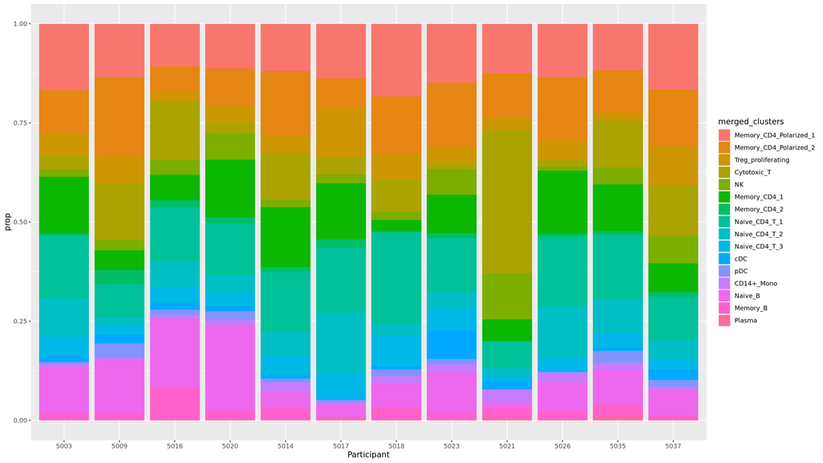

```r
#this is the very basic plot that has everything normalized, it looks pretty but we know emperically its better to put each bar separately for comparison
ggplot(meta_tots_by_part, aes(x=Participant, y=prop, fill=merged_clusters))+geom_col()
```

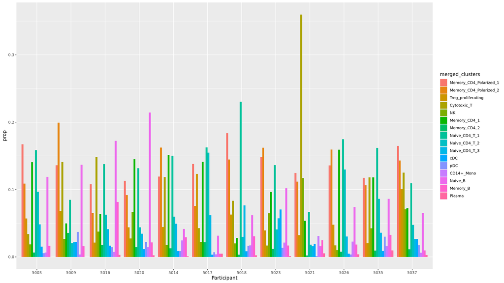

```r
#doing it like this separates things up by the participants, but we want them by clusters
ggplot(meta_tots_by_part, aes(x=Participant, y=prop, fill=merged_clusters))+geom_col(position="dodge")
```

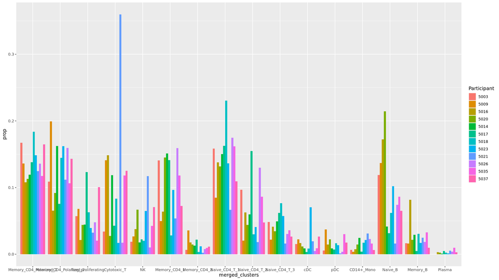

```r
#doing it this way, we can see there is some variation by participants, but perhaps most interestingly is that the groups of 4 also have some variation, with Naive_B being semingly up in methadone, but its still hard to see because there are too many groups
#in general we'll know to be skeptical of Cyotoxic T as that's clearly a large outlier, but for the most part the outiers are not drastically different in other clusters.
ggplot(meta_tots_by_part, aes(x=merged_clusters, y=prop, fill=Participant))+geom_col(position="dodge")
```

```r
#repeating the above, but carrying through the treatment so we can group by that instead
#first factoring treatment to the order I want
meta$Treatment<-factor(meta$Treatment, levels = c("Methadone","Bup.Nalo","Naltrexone"))
meta_tots_by_part<-group_by(meta, Treatment, Participant, merged_clusters, .drop=FALSE)%>%summarise(n=n())%>%mutate(prop=n/sum(n))%>%ungroup()
```

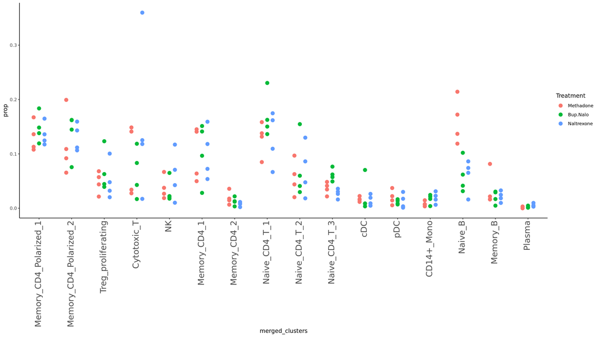

```r
#need to do an extra filter since the factor treatment is creating NAN columns.
meta_tots_by_part<-meta_tots_by_part[!is.nan(meta_tots_by_part$prop),]
#added some extra visual variables since the plot could be useful. From this you cans ee the only major difference across groups is in Naive B cells, with all other groups heavily overlapping
ggplot(meta_tots_by_part, aes(x=merged_clusters, y=prop, group=Treatment, color=Treatment))+geom_point(position=position_dodge(width = 0.5), size=3)+theme_classic()+theme(axis.text.x = element_text(angle = 90, vjust = 0.3, hjust = 1, size = 16))
```

```r
#both are significant parametrically
t.test(meta_tots_by_part$prop[meta_tots_by_part$Treatment=="Methadone" & meta_tots_by_part$merged_clusters=="Naive_B"], meta_tots_by_part$prop[meta_tots_by_part$Treatment=="Naltrexone" & meta_tots_by_part$merged_clusters=="Naive_B"])
```

```
##
##  Welch Two Sample t-test
##
## data:  meta_tots_by_part$prop[meta_tots_by_part$Treatment == "Methadone" & meta_tots_by_part$merged_clusters == "Naive_B"] and meta_tots_by_part$prop[meta_tots_by_part$Treatment == "Naltrexone" & meta_tots_by_part$merged_clusters == "Naive_B"]
## t = 3.8389, df = 5.4896, p-value = 0.01016
## alternative hypothesis: true difference in means is not equal to 0
## 95 percent confidence interval:
##  0.03484358 0.16543465
## sample estimates:
##  mean of x  mean of y
## 0.16053750 0.06039838
```

```r
t.test(meta_tots_by_part$prop[meta_tots_by_part$Treatment=="Methadone" & meta_tots_by_part$merged_clusters=="Naive_B"], meta_tots_by_part$prop[meta_tots_by_part$Treatment=="Bup.Nalo" & meta_tots_by_part$merged_clusters=="Naive_B"])
```

```
##
##  Welch Two Sample t-test
##
## data:  meta_tots_by_part$prop[meta_tots_by_part$Treatment == "Methadone" & meta_tots_by_part$merged_clusters == "Naive_B"] and meta_tots_by_part$prop[meta_tots_by_part$Treatment == "Bup.Nalo" & meta_tots_by_part$merged_clusters == "Naive_B"]
## t = 3.864, df = 5.5308, p-value = 0.009743
## alternative hypothesis: true difference in means is not equal to 0
## 95 percent confidence interval:
##  0.0358163 0.1668330
## sample estimates:
##  mean of x  mean of y
## 0.16053750 0.05921283
```

```r
#and non parametrically
wilcox.test(meta_tots_by_part$prop[meta_tots_by_part$Treatment=="Methadone" & meta_tots_by_part$merged_clusters=="Naive_B"], meta_tots_by_part$prop[meta_tots_by_part$Treatment=="Naltrexone" & meta_tots_by_part$merged_clusters=="Naive_B"])
```

```
##
##  Wilcoxon rank sum exact test
##
## data:  meta_tots_by_part$prop[meta_tots_by_part$Treatment == "Methadone" & meta_tots_by_part$merged_clusters == "Naive_B"] and meta_tots_by_part$prop[meta_tots_by_part$Treatment == "Naltrexone" & meta_tots_by_part$merged_clusters == "Naive_B"]
## W = 16, p-value = 0.02857
## alternative hypothesis: true location shift is not equal to 0
```

```r
wilcox.test(meta_tots_by_part$prop[meta_tots_by_part$Treatment=="Methadone" & meta_tots_by_part$merged_clusters=="Naive_B"], meta_tots_by_part$prop[meta_tots_by_part$Treatment=="Bup.Nalo" & meta_tots_by_part$merged_clusters=="Naive_B"])
```

```
##
##  Wilcoxon rank sum exact test
##
## data:  meta_tots_by_part$prop[meta_tots_by_part$Treatment == "Methadone" & meta_tots_by_part$merged_clusters == "Naive_B"] and meta_tots_by_part$prop[meta_tots_by_part$Treatment == "Bup.Nalo" & meta_tots_by_part$merged_clusters == "Naive_B"]
## W = 16, p-value = 0.02857
## alternative hypothesis: true location shift is not equal to 0
```

## Plotting by treatment and timepoint

Now that we have this difference across treatment groups, we also want to see if things change across timepoints. We can do this two ways:

1. calculate a delta/fold change in each cluster between the two timepoints within an individual (1 datapoint per individual per cluster)
2. Plot groups of cells as above but adding timepoint as a covariate (2 datapoints per individual per cluster)

Option 1 is cleaner but has the potential to obscure outliers and variance, option 2 will be more messy (and thus harder to compare) but show the data more completely.

I do both below.

```r
#method 1, FC
#first factoring timeppoint to the order I want
meta$Timepoint<-factor(meta$Timepoint, levels = c(0,3))

meta_tots_by_part<-group_by(meta, Treatment,Timepoint, Participant, merged_clusters, .drop=FALSE)%>%summarise(n=n())%>%mutate(prop=n/sum(n))%>%ungroup()
```

```
## You can override using the `.groups` argument.
```

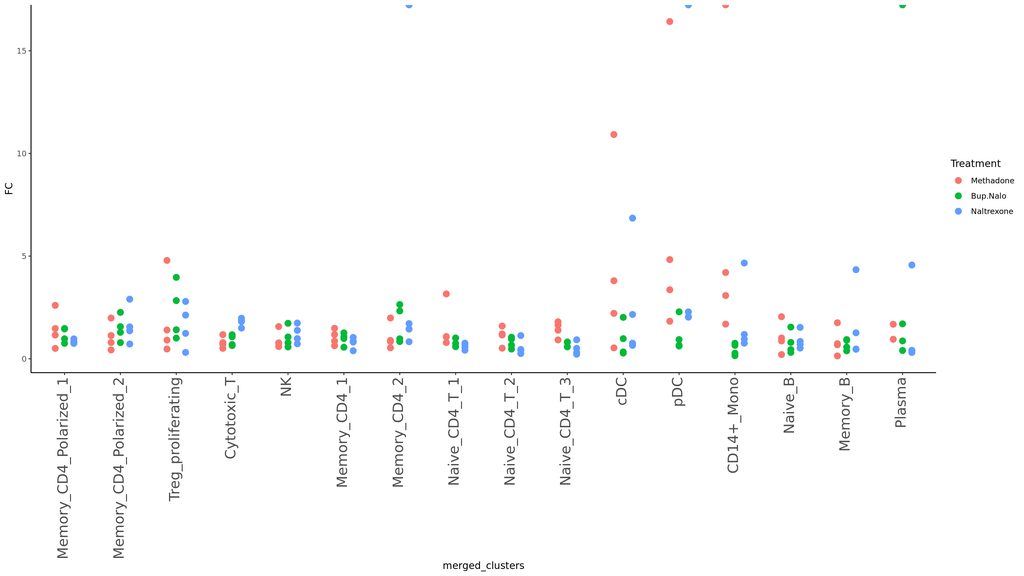

```r
#need to do an extra filter since the factor treatment is creating NAN columns.
meta_tots_by_part<-meta_tots_by_part[!is.nan(meta_tots_by_part$prop),]

#now we need to split by timepoint and calculate a ratio to plot
meta_tots_by_part<-split(meta_tots_by_part, meta_tots_by_part$Timepoint)

meta_tots_by_part$`3`<-meta_tots_by_part$`3`[, c("Treatment","Participant","merged_clusters","prop")]
meta_tots_by_part$`0`<-meta_tots_by_part$`0`[, c("Treatment","Participant","merged_clusters","prop")]
colnames(meta_tots_by_part$`3`)<-c("Treatment","Participant","merged_clusters","prop3")
meta_tots_by_part<-merge(meta_tots_by_part$`0`,meta_tots_by_part$`3`, by=c("Treatment","Participant","merged_clusters") )
meta_tots_by_part$FC<-meta_tots_by_part$prop3/meta_tots_by_part$prop

#uncropped, we can see there are some outliers and some trends, with expansion of the myeloid compartment in methadone, but we need to get closer
ggplot(meta_tots_by_part, aes(x=merged_clusters, y=FC, group=Treatment, color=Treatment))+geom_point(position=position_dodge(width = 0.5), size=3)+theme_classic()+theme(axis.text.x = element_text(angle = 90, vjust = 0.3, hjust = 1, size = 16))
```

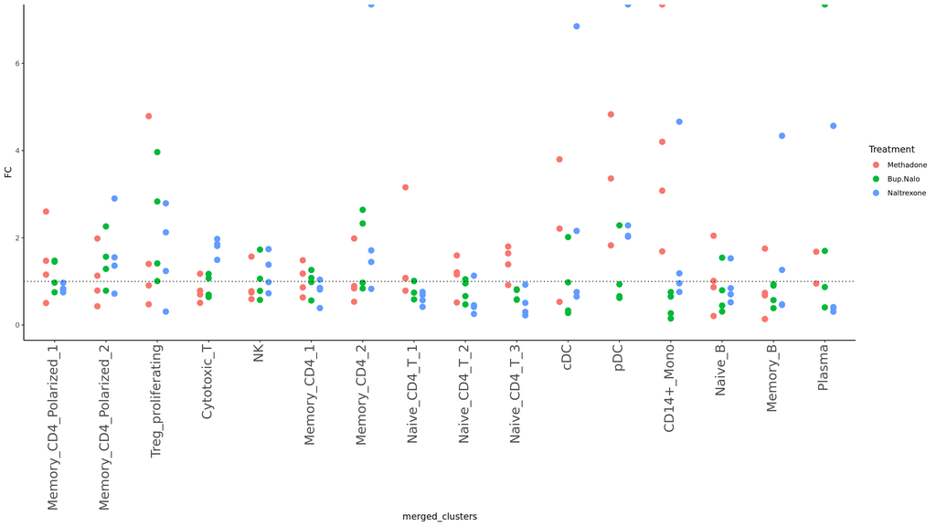

```r
#from this its a little more clear that there are potential differences in the groups, but nothing looks like a smoking gun to test. We're going to need to try anova, but since we have so many more groups than samples it will be unlikely to pick anything up. Since Naive B are not different in terms of fold change here, it suggests that those invididuals were higher from that start
#methadone has higher in the meyloid compartmnet with postivie FC in all participants and all clusters except one cluster in one participant
#interestingly, the Treg proliferating cluster looks like it's on an upward trajectory as well but not for methadone only the others
#a publication ready version of this would probably want to clip the upper features
ggplot(meta_tots_by_part, aes(x=merged_clusters, y=FC, group=Treatment, color=Treatment))+geom_point(position=position_dodge(width = 0.5), size=3)+theme_classic()+theme(axis.text.x = element_text(angle = 90, vjust = 0.3, hjust = 1, size = 16))+ylim(0,7)+geom_hline(yintercept = 1, linetype=3)
```

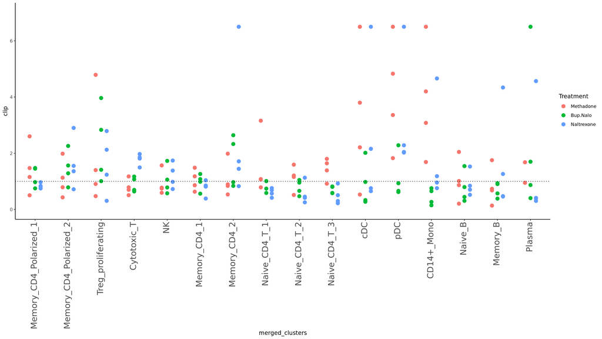

```r
#simple clip
meta_tots_by_part$clip<-meta_tots_by_part$FC
meta_tots_by_part$clip[meta_tots_by_part$clip>6.5]<-6.5
ggplot(meta_tots_by_part, aes(x=merged_clusters, y=clip, group=Treatment, color=Treatment))+geom_point(position=position_dodge(width = 0.5), size=3)+theme_classic()+theme(axis.text.x = element_text(angle = 90, vjust = 0.3, hjust = 1, size = 16))+ylim(0,7)+geom_hline(yintercept = 1, linetype=3)
```

```r
#first remove Inf values, setting them and nans to 1 because its often due to really low cell counts in those clusters
meta_tots_by_part$FC[is.infinite(meta_tots_by_part$FC)]<-1
meta_tots_by_part$FC[is.nan(meta_tots_by_part$FC)]<-1

twoway.anova<-aov(FC ~ Treatment * merged_clusters, meta_tots_by_part)
#p value not signficant for the interaction term, does not justify followup testing
summary(twoway.anova)
```

```
##                            Df Sum Sq Mean Sq F value  Pr(>F)
## Treatment                   2  18.46   9.229   4.236 0.01631 *
## merged_clusters            15  80.34   5.356   2.458 0.00312 **
## Treatment:merged_clusters  30  98.26   3.275   1.503 0.05982 .
## Residuals                 144 313.74   2.179
## ---
## Signif. codes:  0 '***' 0.001 '**' 0.01 '*' 0.05 '.' 0.1 ' ' 1
```

```r
#method 2, all data
meta$T_Tp<-paste(meta$Treatment, meta$Timepoint, sep = "_")
meta$T_Tp<-factor(meta$T_Tp, levels = c("Methadone_0","Methadone_3","Bup.Nalo_0", "Bup.Nalo_3", "Naltrexone_0", "Naltrexone_3"))

meta_tots_by_part<-group_by(meta, T_Tp, Participant, merged_clusters, .drop=FALSE)%>%summarise(n=n())%>%mutate(prop=n/sum(n))%>%ungroup()
```

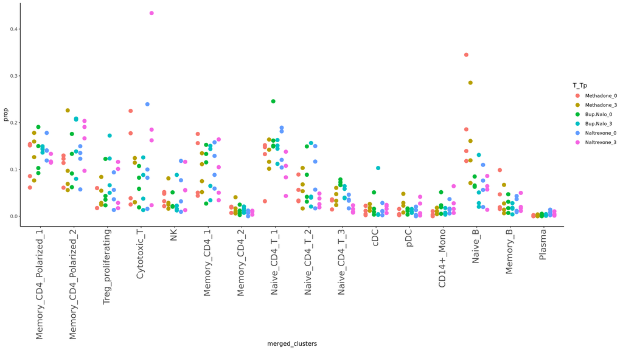

```r
meta_tots_by_part<-meta_tots_by_part[!is.nan(meta_tots_by_part$prop),]
#this one ends up being pretty interesting because we can actually see the changes, particularly negative ones. It might be good to log the fold change above to make it symmetric...
ggplot(meta_tots_by_part, aes(x=merged_clusters, y=prop, group=T_Tp, color=T_Tp))+geom_point(position=position_dodge(width = 0.75), size=3)+theme_classic()+theme(axis.text.x = element_text(angle = 90, vjust = 0.3, hjust = 1, size = 16))
```

```r
#method 1 but symmetric via log transform
meta_tots_by_part<-group_by(meta, Treatment,Timepoint, Participant, merged_clusters, .drop=FALSE)%>%summarise(n=n())%>%mutate(prop=n/sum(n))%>%ungroup()
```

```
## You can override using the `.groups` argument.
```

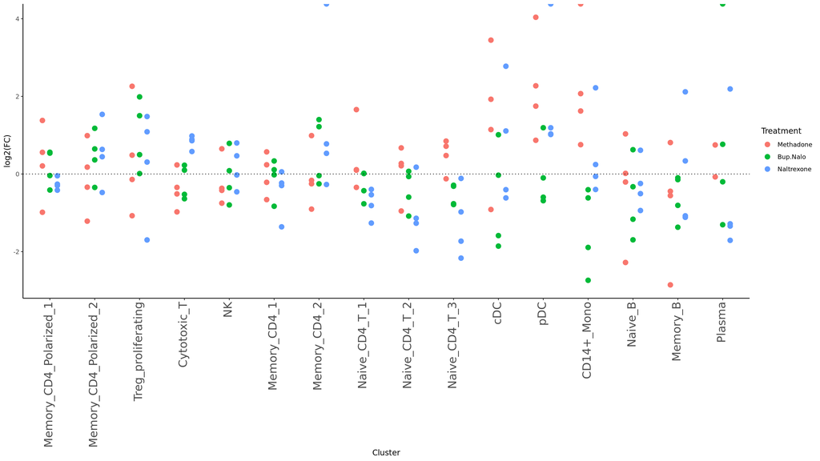

```r
#need to do an extra filter since the factor treatment is creating NAN columns.
meta_tots_by_part<-meta_tots_by_part[!is.nan(meta_tots_by_part$prop),]

#now we need to split by timepoint and calculate a ratio to plot
meta_tots_by_part<-split(meta_tots_by_part, meta_tots_by_part$Timepoint)

meta_tots_by_part$`3`<-meta_tots_by_part$`3`[, c("Treatment","Participant","merged_clusters","prop")]
meta_tots_by_part$`0`<-meta_tots_by_part$`0`[, c("Treatment","Participant","merged_clusters","prop")]
colnames(meta_tots_by_part$`3`)<-c("Treatment","Participant","merged_clusters","prop3")
meta_tots_by_part<-merge(meta_tots_by_part$`0`,meta_tots_by_part$`3`, by=c("Treatment","Participant","merged_clusters") )
meta_tots_by_part$FC<-log2(meta_tots_by_part$prop3/meta_tots_by_part$prop)

#replotted with log scale on the Y, we can see more interesting features. Probably the best iteration so that we can see everything
ggplot(meta_tots_by_part, aes(x=merged_clusters, y=FC, group=Treatment, color=Treatment))+geom_point(position=position_dodge(width = 0.5), size=3)+theme_classic()+theme(axis.text.x = element_text(angle = 90, vjust = 0.3, hjust = 1, size = 16))+geom_hline(yintercept = 0, linetype=3)+ylab("log2(FC)")+xlab("Cluster")
```

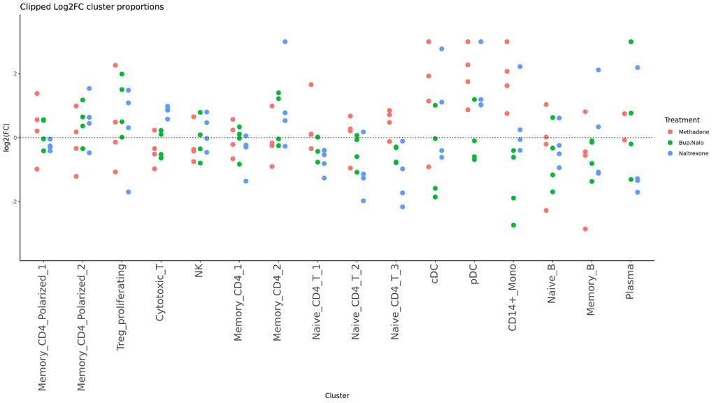

```r
#simple clip
meta_tots_by_part$clip<-meta_tots_by_part$FC
meta_tots_by_part$clip[meta_tots_by_part$clip>3]<-3
meta_tots_by_part$clip[meta_tots_by_part$clip< -3]<- -3

ggplot(meta_tots_by_part, aes(x=merged_clusters, y=clip, group=Treatment, color=Treatment))+geom_point(position=position_dodge(width = 0.5), size=3)+theme_classic()+theme(axis.text.x = element_text(angle = 90, vjust = 0.3, hjust = 1, size = 16))+geom_hline(yintercept = 0, linetype=3)+ylab("log2(FC)")+xlab("Cluster")+ylim(c(-3.5,3.5))+ggtitle("Clipped Log2FC cluster proportions")
```

```r
meta_tots_by_part$FC[is.infinite(meta_tots_by_part$FC)]<-0
meta_tots_by_part$FC[is.nan(meta_tots_by_part$FC)]<-0

twoway.anova<-aov(FC ~ Treatment * merged_clusters, meta_tots_by_part)
#p value now significant on the transformed values, follow ups justified
summary(twoway.anova)
```

```
##                            Df Sum Sq Mean Sq F value  Pr(>F)
## Treatment                   2   7.25   3.624   4.116 0.01827 *
## merged_clusters            15  31.40   2.094   2.378 0.00432 **
## Treatment:merged_clusters  30  47.51   1.584   1.798 0.01215 *
## Residuals                 144 126.79   0.881
## ---
## Signif. codes:  0 '***' 0.001 '**' 0.01 '*' 0.05 '.' 0.1 ' ' 1
```

```r
#follow up comparisons

clusters<-names(table(meta_tots_by_part$merged_clusters))
treatments<-names(table(meta_tots_by_part$Treatment))

for(i in clusters){
  for(j in 1:3){
    if(j==3){
      k=1
    }else{
      k=j+1
    }
    results<-t.test(meta_tots_by_part$FC[meta_tots_by_part$merged_clusters==i & meta_tots_by_part$Treatment==treatments[j]],meta_tots_by_part$FC[meta_tots_by_part$merged_clusters==i & meta_tots_by_part$Treatment==treatments[k]])
    if(results$p.value<0.05){
      print(i)
      print(paste(treatments[j], "vs", treatments[k]))
      print(results)
    }
  }
}
```

```
## [1] "Cytotoxic_T"
## [1] "Bup.Nalo vs Naltrexone"
##
##  Welch Two Sample t-test
##
## data:  meta_tots_by_part$FC[meta_tots_by_part$merged_clusters == i & meta_tots_by_part$Treatment == treatments[j]] and meta_tots_by_part$FC[meta_tots_by_part$merged_clusters == i & meta_tots_by_part$Treatment == treatments[k]]
## t = -4.4243, df = 3.9225, p-value = 0.01199
## alternative hypothesis: true difference in means is not equal to 0
## 95 percent confidence interval:
##  -1.6906165 -0.3806298
## sample estimates:
##  mean of x  mean of y
## -0.2088714  0.8267518
##
## [1] "Cytotoxic_T"
## [1] "Naltrexone vs Methadone"
##
##  Welch Two Sample t-test
##
## data:  meta_tots_by_part$FC[meta_tots_by_part$merged_clusters == i & meta_tots_by_part$Treatment == treatments[j]] and meta_tots_by_part$FC[meta_tots_by_part$merged_clusters == i & meta_tots_by_part$Treatment == treatments[k]]
## t = 4.6406, df = 3.7072, p-value = 0.01165
## alternative hypothesis: true difference in means is not equal to 0
## 95 percent confidence interval:
##  0.4692408 1.9836713
## sample estimates:
##  mean of x  mean of y
##  0.8267518 -0.3997043
##
## [1] "Naive_CD4_T_3"
## [1] "Methadone vs Bup.Nalo"
##
##  Welch Two Sample t-test
##
## data:  meta_tots_by_part$FC[meta_tots_by_part$merged_clusters == i & meta_tots_by_part$Treatment == treatments[j]] and meta_tots_by_part$FC[meta_tots_by_part$merged_clusters == i & meta_tots_by_part$Treatment == treatments[k]]
## t = 3.9934, df = 5.0905, p-value = 0.01002
## alternative hypothesis: true difference in means is not equal to 0
## 95 percent confidence interval:
##  0.366271 1.670144
## sample estimates:
##  mean of x  mean of y
```

[output cut: 28 more lines]

```
##  2.23182574 -0.04822945
##
## [1] "CD14+_Mono"
## [1] "Methadone vs Bup.Nalo"
##
##  Welch Two Sample t-test
##
## data:  meta_tots_by_part$FC[meta_tots_by_part$merged_clusters == i & meta_tots_by_part$Treatment == treatments[j]] and meta_tots_by_part$FC[meta_tots_by_part$merged_clusters == i & meta_tots_by_part$Treatment == treatments[k]]
## t = 3.5179, df = 5.8177, p-value = 0.0132
## alternative hypothesis: true difference in means is not equal to 0
## 95 percent confidence interval:
##  0.7552004 4.2942942
## sample estimates:
## mean of x mean of y
##  1.112331 -1.412417
```

```r
#from this, cytotoxic T, Naive_CD4_T_3, pDC, and CD14+ Mono are all different, nominating those for more careful analysis

#trying it nonparametrically now

for(i in clusters){
  for(j in 1:3){
    if(j==3){
      k=1
    }else{
      k=j+1
    }
    results<-wilcox.test(meta_tots_by_part$FC[meta_tots_by_part$merged_clusters==i & meta_tots_by_part$Treatment==treatments[j]],meta_tots_by_part$FC[meta_tots_by_part$merged_clusters==i & meta_tots_by_part$Treatment==treatments[k]])
    if(results$p.value<0.05){
      print(i)
      print(paste(treatments[j], "vs", treatments[k]))
      print(results)
    }
  }
}
```

```
## [1] "Cytotoxic_T"
## [1] "Bup.Nalo vs Naltrexone"
##
##  Wilcoxon rank sum exact test
##
## data:  meta_tots_by_part$FC[meta_tots_by_part$merged_clusters == i & meta_tots_by_part$Treatment == treatments[j]] and meta_tots_by_part$FC[meta_tots_by_part$merged_clusters == i & meta_tots_by_part$Treatment == treatments[k]]
## W = 0, p-value = 0.02857
## alternative hypothesis: true location shift is not equal to 0
##
## [1] "Cytotoxic_T"
## [1] "Naltrexone vs Methadone"
##
##  Wilcoxon rank sum exact test
##
## data:  meta_tots_by_part$FC[meta_tots_by_part$merged_clusters == i & meta_tots_by_part$Treatment == treatments[j]] and meta_tots_by_part$FC[meta_tots_by_part$merged_clusters == i & meta_tots_by_part$Treatment == treatments[k]]
## W = 16, p-value = 0.02857
## alternative hypothesis: true location shift is not equal to 0
##
## [1] "Naive_CD4_T_1"
## [1] "Naltrexone vs Methadone"
##
##  Wilcoxon rank sum exact test
##
## data:  meta_tots_by_part$FC[meta_tots_by_part$merged_clusters == i & meta_tots_by_part$Treatment == treatments[j]] and meta_tots_by_part$FC[meta_tots_by_part$merged_clusters == i & meta_tots_by_part$Treatment == treatments[k]]
## W = 0, p-value = 0.02857
## alternative hypothesis: true location shift is not equal to 0
##
## [1] "Naive_CD4_T_3"
## [1] "Methadone vs Bup.Nalo"
##
##  Wilcoxon rank sum exact test
##
## data:  meta_tots_by_part$FC[meta_tots_by_part$merged_clusters == i & meta_tots_by_part$Treatment == treatments[j]] and meta_tots_by_part$FC[meta_tots_by_part$merged_clusters == i & meta_tots_by_part$Treatment == treatments[k]]
## W = 16, p-value = 0.02857
## alternative hypothesis: true location shift is not equal to 0
##
## [1] "CD14+_Mono"
## [1] "Methadone vs Bup.Nalo"
##
##  Wilcoxon rank sum exact test
##
## data:  meta_tots_by_part$FC[meta_tots_by_part$merged_clusters == i & meta_tots_by_part$Treatment == treatments[j]] and meta_tots_by_part$FC[meta_tots_by_part$merged_clusters == i & meta_tots_by_part$Treatment == treatments[k]]
## W = 16, p-value = 0.02857
## alternative hypothesis: true location shift is not equal to 0
##
## [1] "CD14+_Mono"
## [1] "Bup.Nalo vs Naltrexone"
##
##  Wilcoxon rank sum exact test
##
## data:  meta_tots_by_part$FC[meta_tots_by_part$merged_clusters == i & meta_tots_by_part$Treatment == treatments[j]] and meta_tots_by_part$FC[meta_tots_by_part$merged_clusters == i & meta_tots_by_part$Treatment == treatments[k]]
## W = 0, p-value = 0.02857
## alternative hypothesis: true location shift is not equal to 0
```

```r
#getting roughly the same for the wilcox test, with cytotoxic T, Naive_CD4_T_3, and CD14+ Mono, but also Naive CD4 T 1 being slightly different, and no pDCs
```

# Conclusions

Based on this proportionality analysis, I would nominate these clusters for further investigation since they had different proportions across treatment groups and/or timepoints: 1. cytotoxic T 2. Naive_CD4_T_3 3. CD14+ Mono 4. Naive CD4 T 1 5. pDCs 6. Naive B cells

Of note, this analysis is limited in terms of FDR correction since we have too small of an N for the proper test (wilcox) since we can’t assume normality at this low of an N.

# Adendum

Below is a further iteration of the final time point plotting but on the CD4. No differences in proportion were significant by ANOVA. Some populations may warrant further investigation if the above do not pan out, but at least for now it looks reasonable.

```r
results<-readRDS("~/gibbs/DOGMAMORPH/Ranalysis/Objects/20230529CD4ObjAnno.rds")
meta<-results@meta.data
meta$Treatment<-factor(meta$Treatment, levels = c("Methadone","Bup.Nalo","Naltrexone"))


meta_tots_by_part<-group_by(meta, Treatment,Timepoint, Participant, CD4anno, .drop=FALSE)%>%summarise(n=n())%>%mutate(prop=n/sum(n))%>%ungroup()
```

```
## You can override using the `.groups` argument.
```

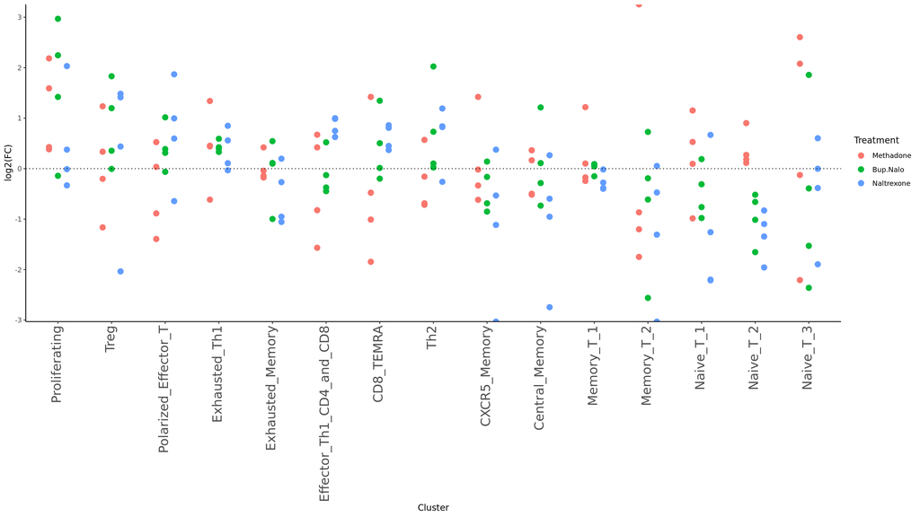

```r
#need to do an extra filter since the factor treatment is creating NAN columns.
meta_tots_by_part<-meta_tots_by_part[!is.nan(meta_tots_by_part$prop),]

#now we need to split by timepoint and calculate a ratio to plot
meta_tots_by_part<-split(meta_tots_by_part, meta_tots_by_part$Timepoint)

meta_tots_by_part$`3`<-meta_tots_by_part$`3`[, c("Treatment","Participant","CD4anno","prop")]
meta_tots_by_part$`0`<-meta_tots_by_part$`0`[, c("Treatment","Participant","CD4anno","prop")]
colnames(meta_tots_by_part$`3`)<-c("Treatment","Participant","CD4anno","prop3")
meta_tots_by_part<-merge(meta_tots_by_part$`0`,meta_tots_by_part$`3`, by=c("Treatment","Participant","CD4anno") )
meta_tots_by_part$FC<-log2(meta_tots_by_part$prop3/meta_tots_by_part$prop)

#replotted with log scale on the Y, we can see more interesting features. Probably the best iteration so that we can see everything
ggplot(meta_tots_by_part, aes(x=CD4anno, y=FC, group=Treatment, color=Treatment))+geom_point(position=position_dodge(width = 0.5), size=3)+theme_classic()+theme(axis.text.x = element_text(angle = 90, vjust = 0.3, hjust = 1, size = 16))+geom_hline(yintercept = 0, linetype=3)+ylab("log2(FC)")+xlab("Cluster")
```

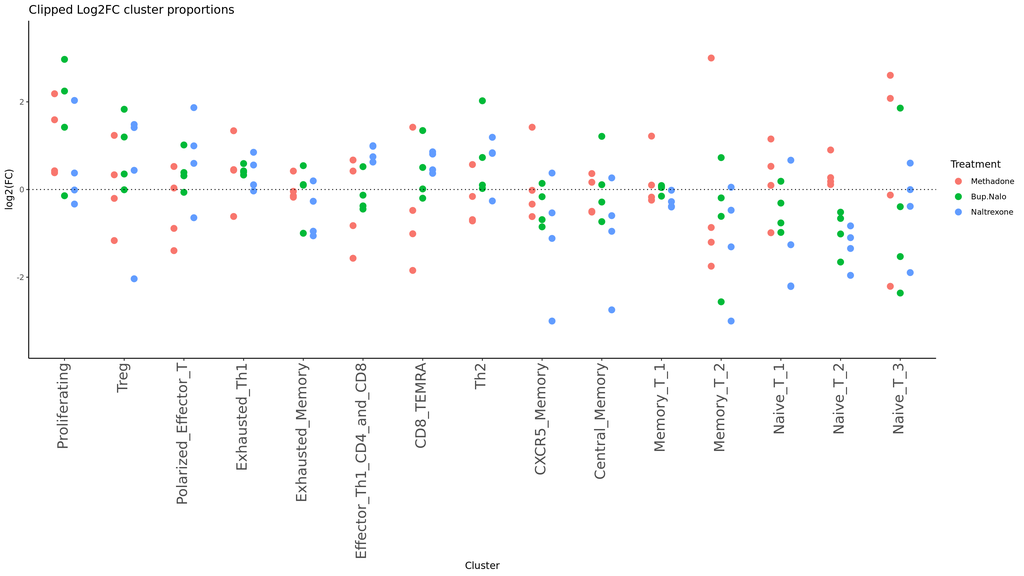

```r
#simple clip
meta_tots_by_part$clip<-meta_tots_by_part$FC
meta_tots_by_part$clip[meta_tots_by_part$clip>3]<-3
meta_tots_by_part$clip[meta_tots_by_part$clip< -3]<- -3

ggplot(meta_tots_by_part, aes(x=CD4anno, y=clip, group=Treatment, color=Treatment))+geom_point(position=position_dodge(width = 0.5), size=3)+theme_classic()+theme(axis.text.x = element_text(angle = 90, vjust = 0.3, hjust = 1, size = 16))+geom_hline(yintercept = 0, linetype=3)+ylab("log2(FC)")+xlab("Cluster")+ylim(c(-3.5,3.5))+ggtitle("Clipped Log2FC cluster proportions")
```

```r
meta_tots_by_part$FC[is.infinite(meta_tots_by_part$FC)]<-0
meta_tots_by_part$FC[is.nan(meta_tots_by_part$FC)]<-0

twoway.anova<-aov(FC ~ Treatment * CD4anno, meta_tots_by_part)
#p value not significant here
summary(twoway.anova)
```

```
##                    Df Sum Sq Mean Sq F value   Pr(>F)
## Treatment           2   1.11  0.5567   0.670 0.513599
## CD4anno            14  37.37  2.6696   3.211 0.000215 ***
## Treatment:CD4anno  28  32.29  1.1531   1.387 0.112514
## Residuals         135 112.24  0.8314
## ---
## Signif. codes:  0 '***' 0.001 '**' 0.01 '*' 0.05 '.' 0.1 ' ' 1
```